# ggplot introduction

### Horizontal bar-plot

- use **y** axis for the variable instead of **x**

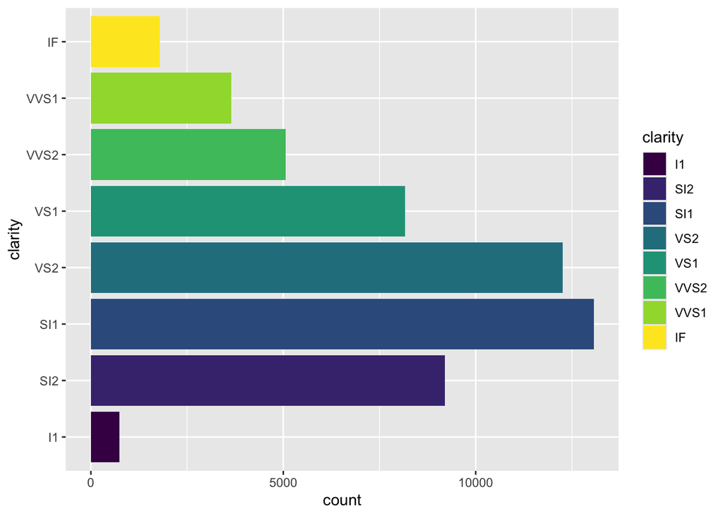

```r
ggplot(data = diamonds,
       mapping = aes(
         y = clarity,
         fill = clarity
       )) +
  geom_bar()
```

Alternatively, we can flip the axis by adding `coord_flip()`:

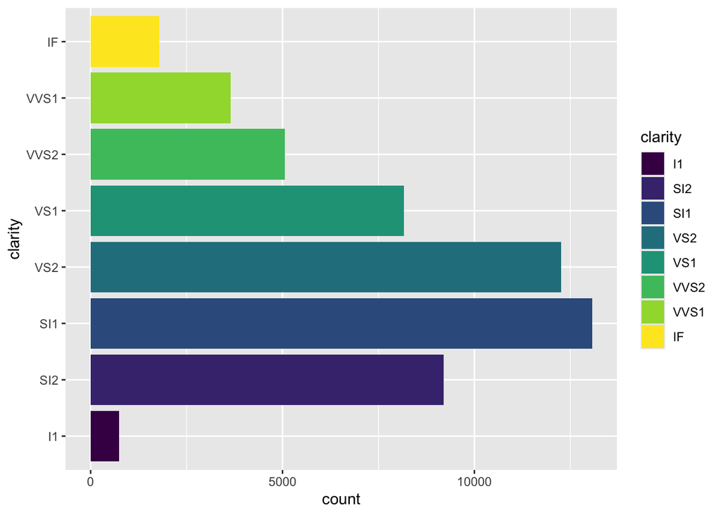

```r
ggplot(data = diamonds,
       mapping = aes(
         x = clarity,
         fill = clarity
       )) +
  geom_bar() +
  coord_flip()
```

### Stacked bar plots

- adding **fill** parameter to aesthetics
- here we are stacking the bars based on **color** variable

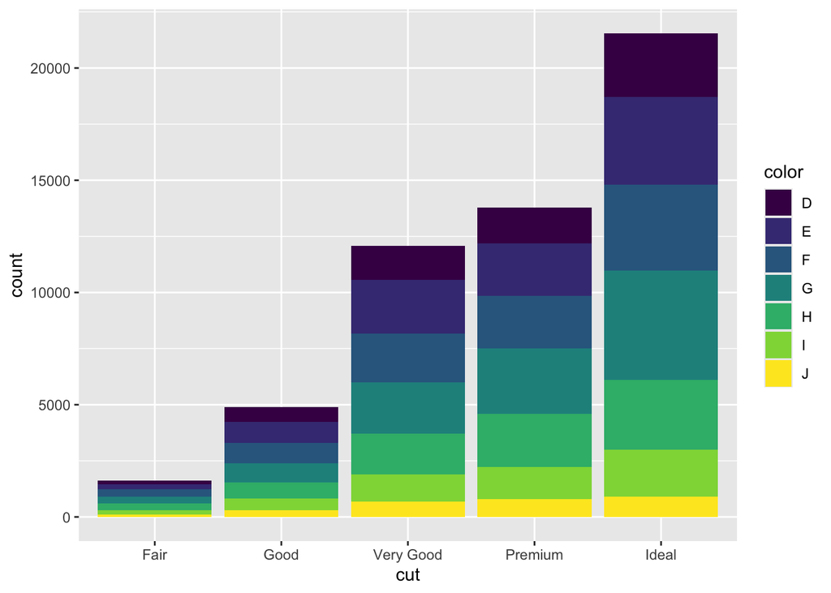

```r
ggplot(data = diamonds,
       mapping = aes(
         x = cut,
         fill = color)) +
  geom_bar()
```

### Grouped bar plots

- add `position = "dodge"` as a parameter of `geom_bar()`

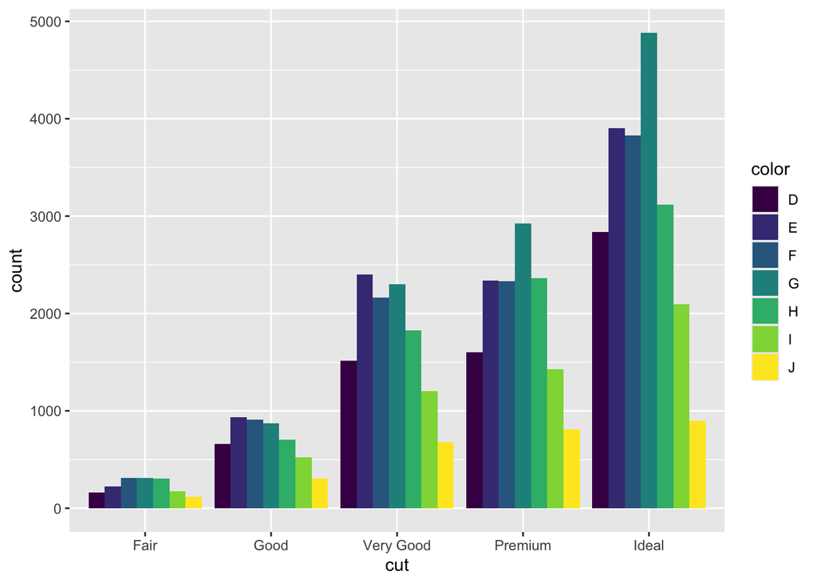

```r
ggplot(data = diamonds,
       mapping = aes(
         x = cut,
         fill = color)) +
  geom_bar(position = "dodge")
```

## Box Plots

- use `geom_boxplot()`

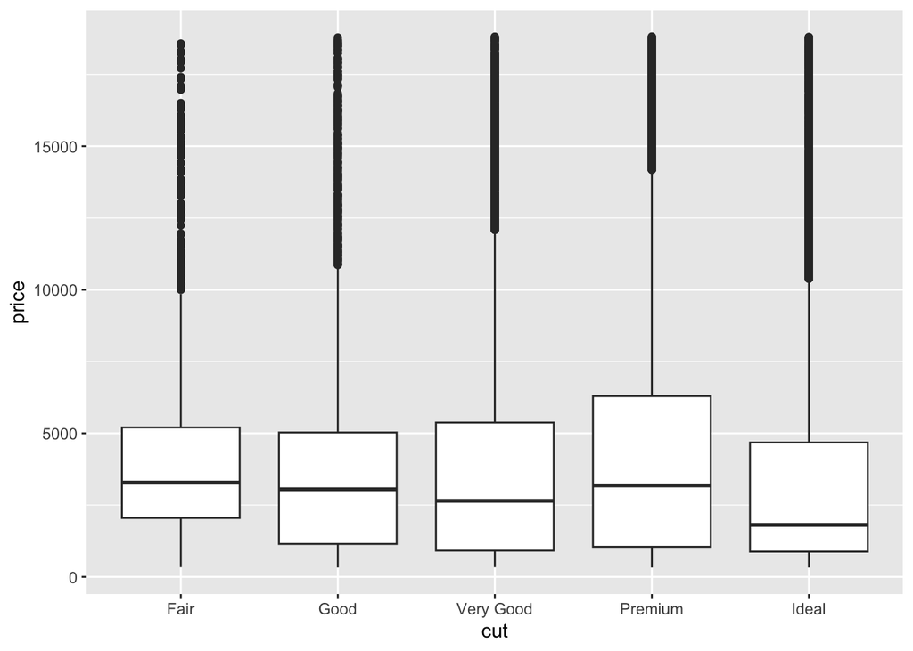

```r
ggplot(data = diamonds,
       mapping = aes(
         x = cut,
         y = price
       )) +
  geom_boxplot()
```

### Box plot with fill

- add **fill** parameter into **`aes()`** function
- in this case the color will be based on **cut** variable

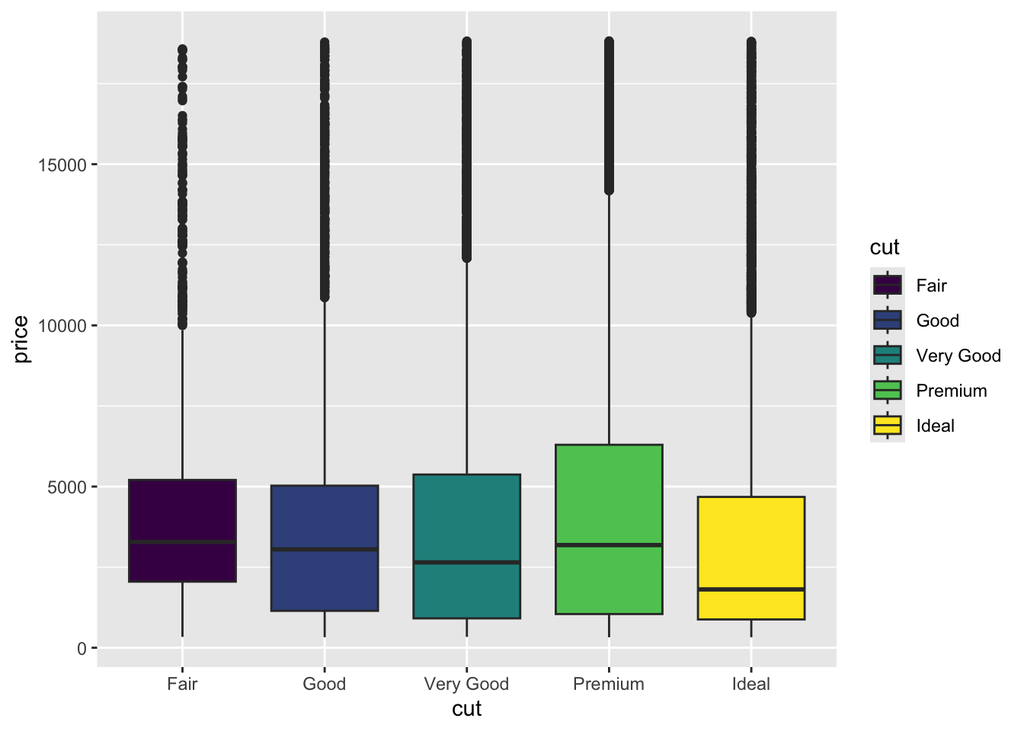

```r
ggplot(data = diamonds,
       mapping = aes(
         x = cut,
         y = price,
         fill = cut)) +
  geom_boxplot()
```

## Scatter plots

- use `geom_point()`

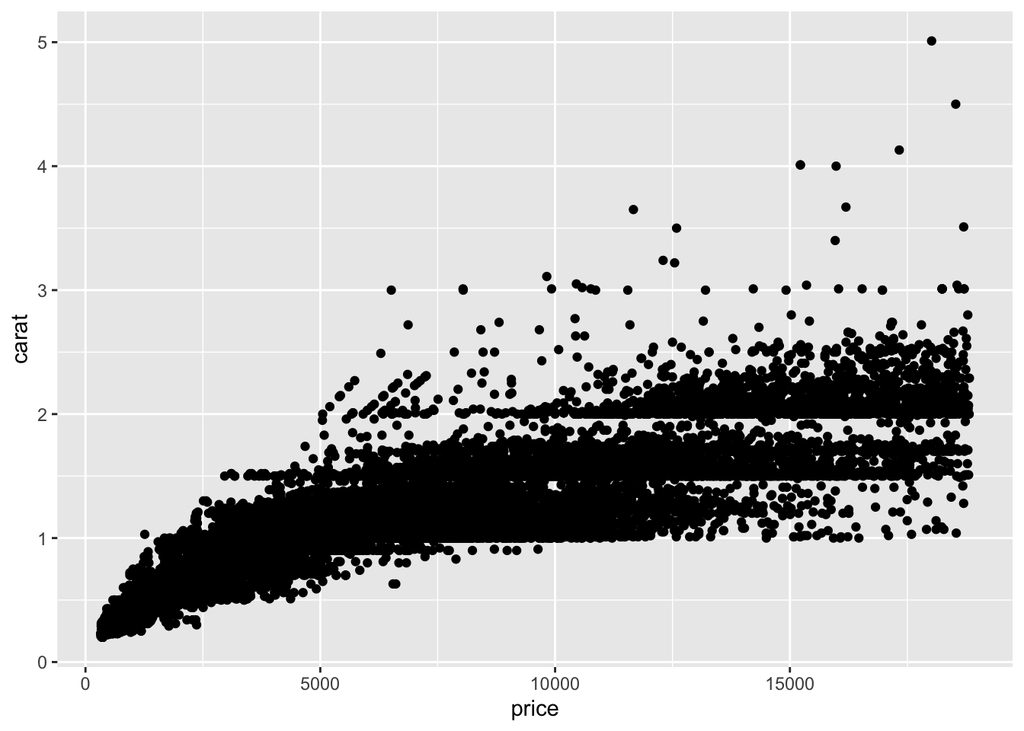

```r
ggplot(data = diamonds,
       mapping = aes(
         x = price,
         y = carat)) +
  geom_point()
```

### Scatter Plot with fill

- add **color** parameter into **`aes()`** function
- in this case the color will be based on **depth** variable
- by default the color will be based on continuous scale
  - if you want to group the continuous variable into categories, you can use binned color scale: add `scale_color_viridis_b()` function

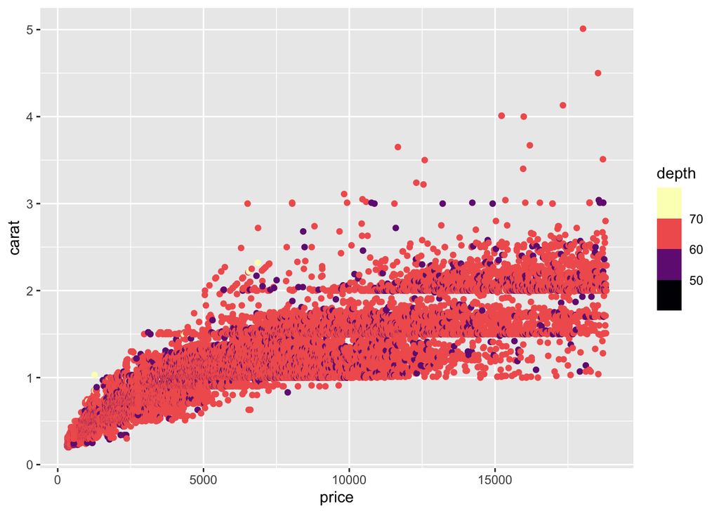

```r
ggplot(data = diamonds,
       mapping = aes(
         x = price,
         y = carat,
         color = depth)) +
  geom_point() + scale_color_viridis_b(option = "magma")
```

## Histograms

- use `geom_histogram`
- you can specify the **bins** parameter

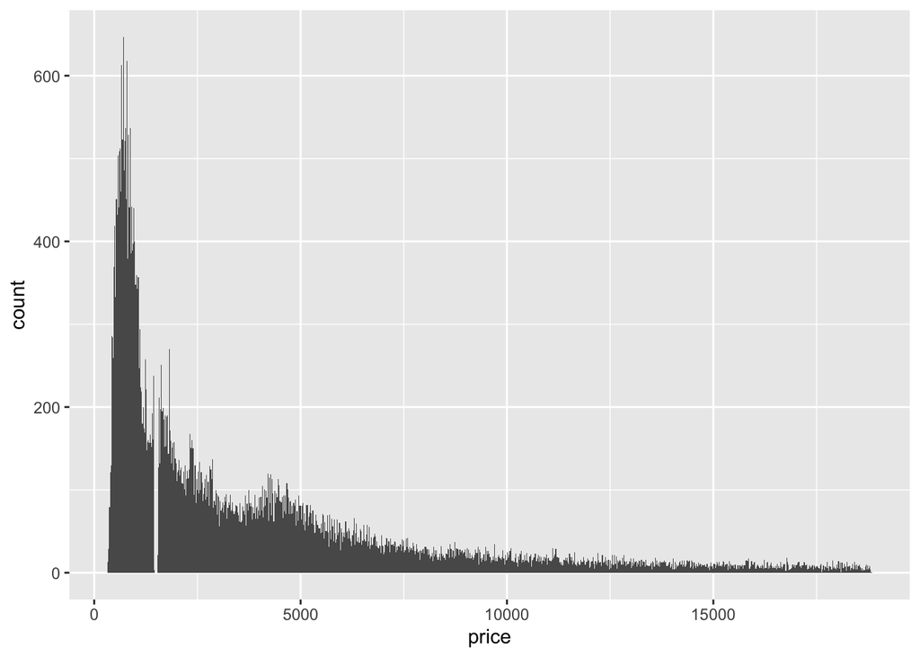

```r
ggplot(data = diamonds,
       mapping = aes(x = price)) +
  geom_histogram(bins = 1000)
```

**Dataset Economics:**

**Variables:**

`date` — the month of data collection

`pce` — personal consumption expenditures in billions of dollars

`pop` — total population in thousands

`psavert` — personal savings rate

`unempmed` — median duration of unemployment in weeks

`unemploy` — number of unemployed in thousands

```r
head(economics)
```

```
## # A tibble: 6 × 6
##   date         pce    pop psavert uempmed unemploy
##   <date>     <dbl>  <dbl>   <dbl>   <dbl>    <dbl>
## 1 1967-07-01  507. 198712    12.6     4.5     2944
## 2 1967-08-01  510. 198911    12.6     4.7     2945
## 3 1967-09-01  516. 199113    11.9     4.6     2958
## 4 1967-10-01  512. 199311    12.9     4.9     3143
## 5 1967-11-01  517. 199498    12.8     4.7     3066
## 6 1967-12-01  525. 199657    11.8     4.8     3018
```

## Line Graphs

- use `geom_line()`

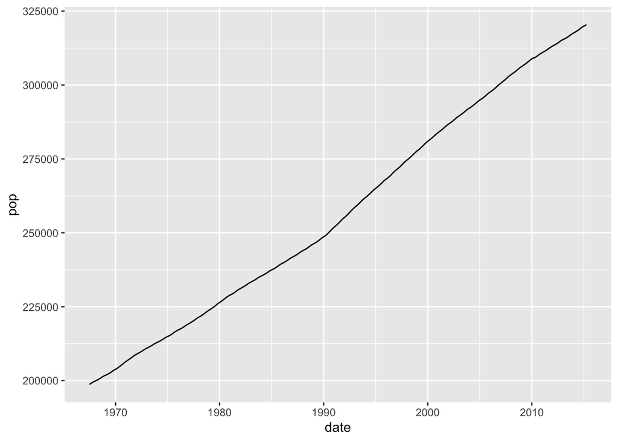

```r
ggplot(data = economics,
       mapping = aes(
         x = date,
         y = pop)) +
  geom_line()
```

## Labeling

Add:

- title: `ggtitle()`
- x-axis label: `xlab()`
- y-axis label: `ylab()`

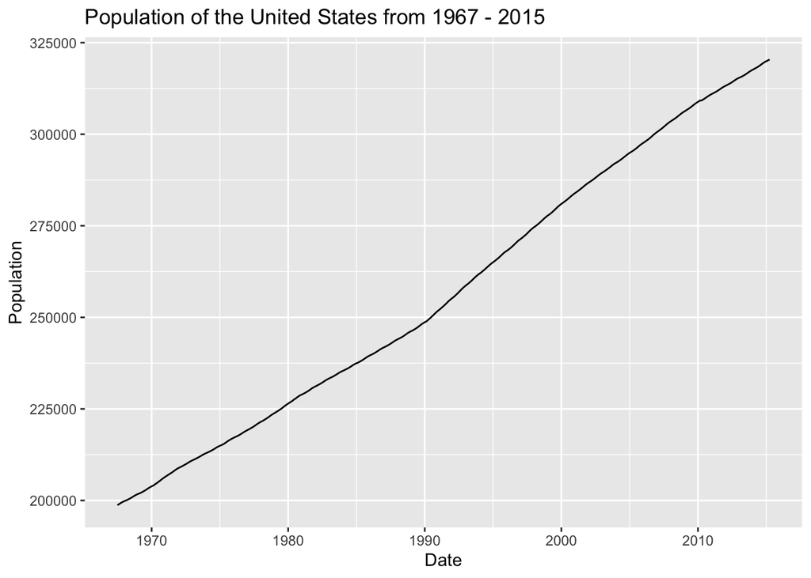

```r
ggplot(data = economics,
       mapping = aes(
         x = date,
         y = pop)) +
  geom_line() +
  ggtitle("Population of the United States from 1967 - 2015") +
  xlab("Date") +
  ylab("Population")
```

## Faceting

- faceting is a technique for creating multiple subplots (facets) based on values of variable
- use `facet_wrap()` to split facets
  - here, `color ~ .` means to create facets based on each unique value of **color** variable

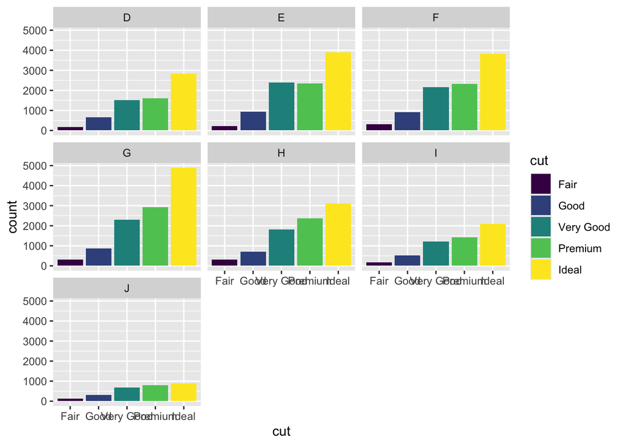

```r
ggplot(data = diamonds,
       mapping = aes(x = cut,
                     fill = cut)) +
  geom_bar() +
  facet_wrap(color ~ .)
```

- use `facet_grid()` to create plots in rows for each level

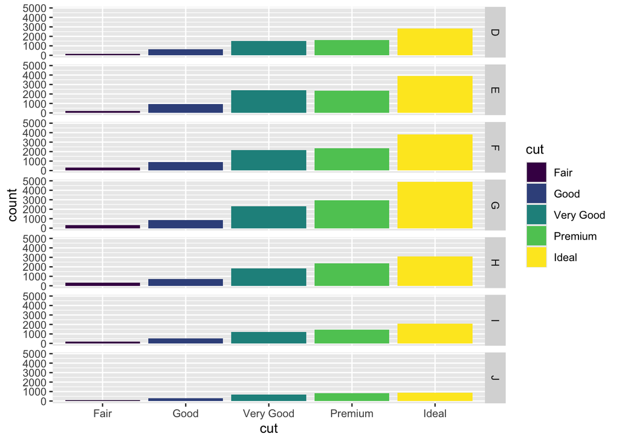

```r
ggplot(data = diamonds,
       mapping = aes(x = cut,
                     fill = cut)) +
  geom_bar() +
  facet_grid(color ~ .)
```